# Plotting data

## In base R

At this point, I’m going to move ahead to plots, before coming back to other ways to manipulate data frames. The reason is simple: plotting my data is usually my first pass at seeing what’s going on. I usually manipulate my data frames for the purpose of plotting it in a particular way, and seeing the data first gives me better ideas of how to manipulate the data frame in order to plot it more informatively.

For the `hs_sorted` data, one question we might ask is how socioeconomic status affects test scores. A boxplot will start to answer this question informatively. In base R, we use the function `boxplot()` to do this. In this function, we see a new character `~`. We read this as “by”. The function below can be read as “make a plot of how the test score value varies by socioeconomic status. Use `hs_sorted` as the data”.

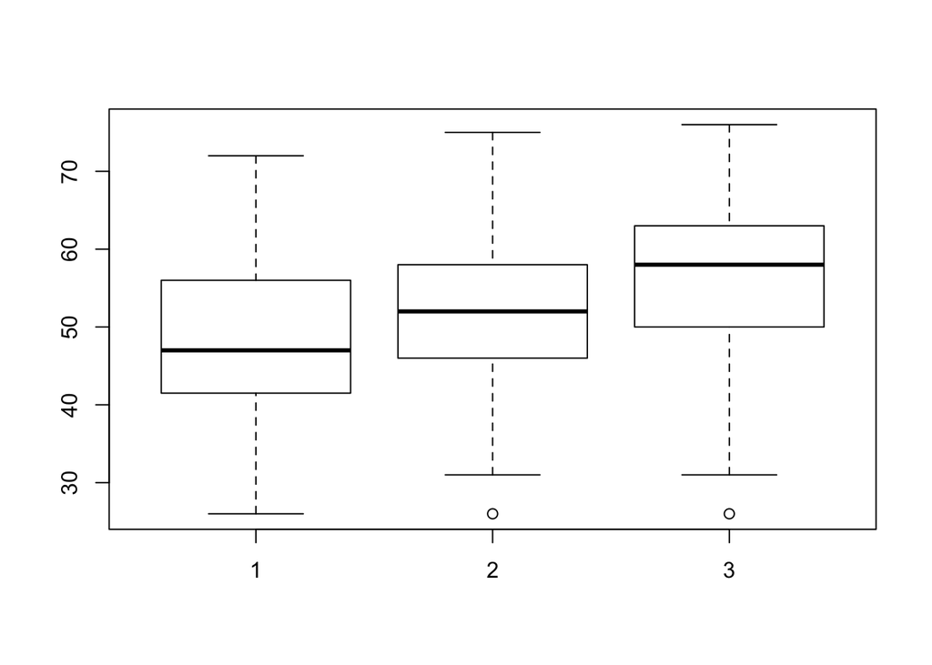

```r
boxplot(value ~ ses, data = hs_sorted)
```

This is a nice first pass at the data. We learn that test scores go up for higher SES scores. Other plot commands in base R include:

| Function | Does |
| --- | --- |
| `boxplot(y ~ x, data = data_frame)` | boxplot |
| `plot(y ~ x, data = data_frame)` | scatter plot |
| `hist(data_frame$column)` | histogram |
| `density(data_frame$column)` | density plot |

For a detailed look at graphics in base R, check out Joe’s [R Study Group](http://www.ling.upenn.edu/~joseff/rstudy/week4.html).

## Making it nice with `ggplot`

I find R’s base plots actually much harder to deal with than `ggplot` (which stands for “graphics of grammar plot”), since base plots are hard to control - so my first step in looking at data is actually to plot it using `ggplot`. Today, I’ll introduce `ggplot`, and tomorrow we’ll go into more detail.

`ggplot` is a package that give you a **lot** of freedom over your plots. Its defaults are set to make beautiful plots, which - let’s face it - makes it easier to convince people that your data is the **real deal**. My go-to for help with `ggplot` is Winston Chang’s [Cookbook for R](http://www.cookbook-r.com/Graphs/). Again, Joe’s [R Study Group](http://www.ling.upenn.edu/~joseff/rstudy/summer2010_ggplot2_intro.html) is also a great tutorial, and Hadley Wickham’s (the author of ggplot) [paper on ggplot](http://vita.had.co.nz/papers/layered-grammar.pdf) provides some more in-depth info on the theory behind `ggplot` as a data visualization tool. I especially recommend reading Section 7 (just one page long) Here’s a teaser:

> How can we build on top of the grammar to help data analysts build compelling, revealing graphics? What would a poetry of graphics look like?

Who doesn’t want their graphics to be compelling and revealing - poetic in their informativeness!? I’m sold. `ggplot` works a little differently than plotting in base R, because it’s not just a single line of code.

### Let’s try it out!

We’ll start with the `ggplot` equivalent of the boxplot that we made above in base graphics. First we need to install and load `ggplot2`.

```r
install.packages("ggplot2")
library(ggplot2)
head(hs_sorted)
```

```
##     id female race ses schtyp prog variable value
## 99   1      1    1   1      1    3     read    34
## 299  1      1    1   1      1    3    write    44
## 499  1      1    1   1      1    3     math    40
## 699  1      1    1   1      1    3  science    39
## 899  1      1    1   1      1    3    socst    41
## 139  2      1    1   2      1    3     read    39
```

The basic way to create a plot is to put the data and aesthetics in the `ggplot()` function, and then add the layers of **geom** and **stat** that you want. The first line calls the data frame as the first argument, and then the list of aesthetic mappings as the second argument.

> `ggplot(data_frame, aes(x = x_var, y = y_var))`

After adding the data, we can make that data materialize with whatever geometric layer we want. We achieve this by adding a `+` to the end of the first line, so that the function knows its not done yet. Most style guides will suggest adding each layer on its own line, to keep the code maximally readable.

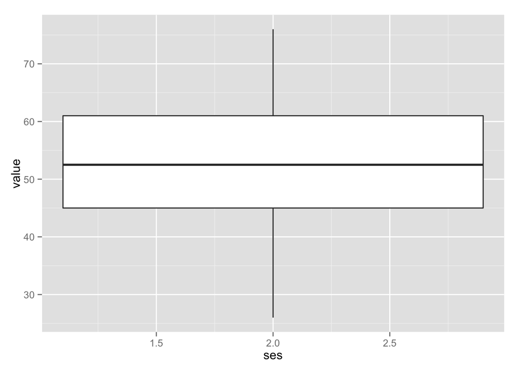

```r
ggplot(hs_sorted, aes(x = ses, y = value)) +
  geom_boxplot()
```

**Something’s wrong here** … Why is `ggplot` only giving us one overall boxplot instead of a separate boxplot for each ses? The answer has to do with how the data is coded. If we take a look at the `summary` of `hs_sorted`, we can see that R thinks that `ses` is a measurement on a scale. It tells us that 2.055 is the mean socioeconomic status of this dataset. But this is silly: we know that students are given a discrete score of either 1, 2, or 3. In other words, even though `ses` is represented as a numeric variable, it’s actually a **factor** variable. It increases in discrete steps.

```r
summary(hs_sorted)
```

```
##        id             female           race           ses
##  Min.   :  1.00   Min.   :0.000   Min.   :1.00   Min.   :1.000
##  1st Qu.: 50.75   1st Qu.:0.000   1st Qu.:3.00   1st Qu.:2.000
##  Median :100.50   Median :1.000   Median :4.00   Median :2.000
##  Mean   :100.50   Mean   :0.545   Mean   :3.43   Mean   :2.055
##  3rd Qu.:150.25   3rd Qu.:1.000   3rd Qu.:4.00   3rd Qu.:3.000
##  Max.   :200.00   Max.   :1.000   Max.   :4.00   Max.   :3.000
##      schtyp          prog          variable       value
##  Min.   :1.00   Min.   :1.000   read   :200   Min.   :26.00
##  1st Qu.:1.00   1st Qu.:2.000   write  :200   1st Qu.:45.00
##  Median :1.00   Median :2.000   math   :200   Median :52.50
##  Mean   :1.16   Mean   :2.025   science:200   Mean   :52.38
##  3rd Qu.:1.00   3rd Qu.:2.250   socst  :200   3rd Qu.:61.00
##  Max.   :2.00   Max.   :3.000                 Max.   :76.00
```

Factors are actually a litte complicated. Underlyingly, they are numeric values that are represented with character strings. This mostly has implications for statistical analysis, which we won’t be getting into in this mini course. But it’s good to know that when you have e.g, gender represented as a factor (which is R’s default representation for character variables), it is underlying a series of 0 and 1.

For the purpose of plotting the data in an informative way, all we need to do is realize that the `ses` variable looks linear to `ggplot`, but that we intend it to be a factor. Easy! We can coerce variables into other data types by using the following:

| Function | Does |
| --- | --- |
| `as.factor()` | coerce to factor |
| `as.character()` | coerce to character string |
| `as.numeric()` | coerce to numbers |

For this data, we need to coerce `ses` to a factor. We can do this either outside of the `ggplot` function or within it. The following are equivalent:

```r
## change the data frame and then plot it (good for if you want to continue working with ses as a factor)

hs_sorted$ses <- as.factor(hs_sorted$ses)
ggplot(hs_sorted, aes(x = ses, y = value)) +
  geom_boxplot()

## change the variable just when you plot it
ggplot(hs_sorted, aes(x = as.factor(ses), y = value)) +
  geom_boxplot()
```

Both of these options produce the graph we’re looking for:

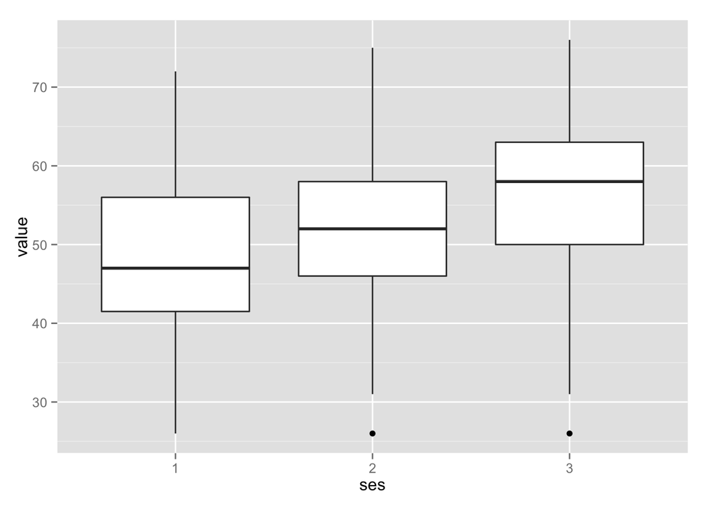

### More ways to visualize with `ggplot`

Let’s see whether gender has an additional effect on test scores. Note that the gender variable gives us the same problem as the socioeconomic status variable, so we have to also coerce it to a factor first.

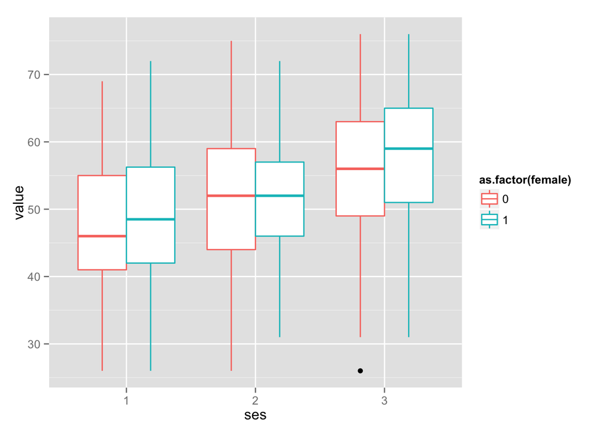

```r
ggplot(hs_sorted, aes(x = ses, y = value, color = as.factor(female))) +
  geom_boxplot()
```

Beautiful! What else might be informative? Maybe there’s a difference in subject score by socioeconomic status, or by gender? Note that here I’m also changing the `color` aesthetic mapping to a `fill`, because I want the boxes to be filled with color instead of just changing the color of the lines.

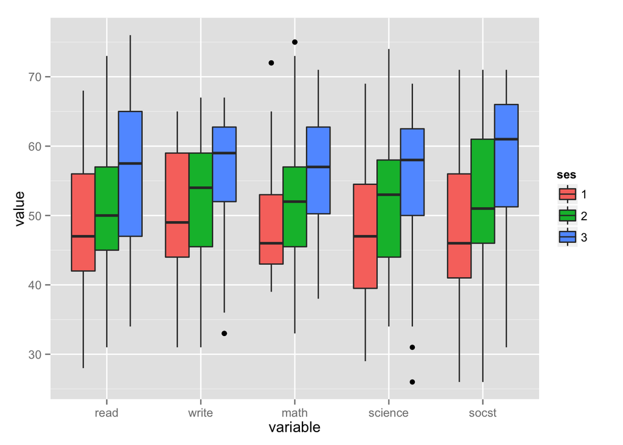

```r
ggplot(hs_sorted, aes(x = variable, y = value, fill = ses)) +
  geom_boxplot()
```

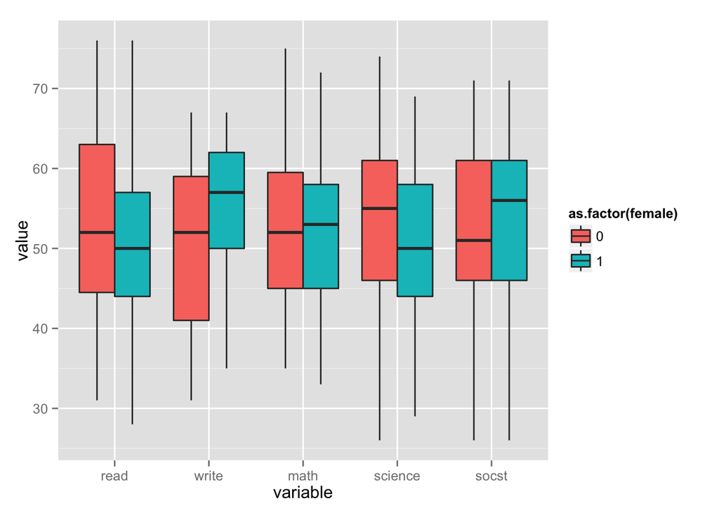

```r
ggplot(hs_sorted, aes(x = variable, y = value, fill = as.factor(female))) +
  geom_boxplot()
```

## Arguments and Layers

Below is a list of some of the aesthetic options, geoms, stat layers, and fine-tuning arguments that I use regularly. This is not a full list! (see [ggplot documentation](http://docs.ggplot2.org/current/)) for a current list of layers supported by ggplot.

#### Aesthetic arguments

| Argument | Does |
| --- | --- |
| `x =` | assigns variable to x. Not optional. |
| `y =` | assigns variable to y |
| `color =` | assigns color of lines or points. Note that `colour =` also works |
| `fill =` | assigns the fill of 2-dimensional shapes |
| `size =` | assigns size (of points or line width) |
| `shape =` | assigns shape |
| `alpha =` | assigns transparency |
| `linetype =` | assigns line type |
| `label =` | assigns text (for use with `geom_text()`) |

#### Geometric levels

| Geom | Makes |
| --- | --- |
| `geom_point()` | scatterplot |
| `geom_bar(stat = "identity")` | barplot |
| `geom_boxplot()` | boxplot |
| `geom_violinplot()` | violin plot |
| `geom_line()` | line plot (connects points left to right) |
| `geom_path()` | line plot (connects points in the order they appear in the data frame) |
| `geom_area()` | area plot (filled in from line to x axis) |
| `geom_text()` | scatterplot of text |
| `geom_blank()` | draws a blank layer. Unclear why this exists. |
| `geom_contour()` | contour plot |
| `geom_histogram()` | histogram |
| `geom_errorbar()` | error bars |
| `geom_jitter()` | points - jittered (to reduce overlap) |

#### Statistic levels

| Stat | Does |
| --- | --- |
| `stat_smooth()` | smoothed line |
| `stat_density()` | density plot |
| `stat_summary()` | summarize y value for each x |

#### Scale assignment

| Scale | Does |
| --- | --- |
| `scale_alpha()` | set alpha range |
| `scale_area()` | scale area instead of radius for `size` aesthetic |
| `scale_color_gradient()` | smooth gradient bewteen two colors |
| `scale_color_grey()` | gray scale |
| `scale_manual()` | set alpha, color, fill, linetype, shape, size, manually |
| `scale_linetype()` | set linetype scale |
| `scale_size()` | set size range |
| `scale_x()` | adjust x: reverse it, put in log space, |

#### Labels and themes

| Function | Does |
| --- | --- |
| `labs()` | add title, x axis, y axis, legend titles |
| `xlim()` | change limits of x axis |
| `ylim()` | change limits of y axis |
| `theme_bw()` | white background, black gridlines |
| `theme_grey()` | grey background, white gridlines |
| `theme()` | set theme elements (text size, linetype, etc.) |

#### An example with the `hs_sorted` data

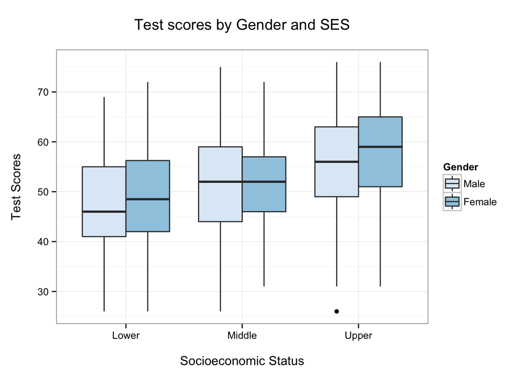

```r
ggplot(hs_sorted, aes(x = ses, y = value, fill = as.factor(female))) +
  geom_boxplot() +
  labs(x = "\nSocioeconomic Status", y = "Test Scores\n", fill = "Gender", title = "Test scores by Gender and SES\n") +
  scale_fill_brewer(breaks = c(0, 1),
                    labels = c("Male", "Female")) +
  scale_x_discrete(breaks = c(1, 2, 3),
                   labels = c("Lower", "Middle", "Upper")) +
  theme_bw()
```

[^1]: Thanks to Daniel Ezra Johnson for pointing this out!